# Tugas MPDW Pertemuan 4

Yasmin Aufaahani Abdullah-M0401241129

2026-09-17

```r
library(TSA)
```

# Proses MA(2)

```r
set.seed (129)

n<-300
theta1<- 0.4
theta2<- 0.6
```

## Pembangkitan Manual

```r
e <- rnorm(n,mean=0, sd=1)
manual <- numeric (n)

manual[1] <- e[1]
manual[2] <- e[2] + theta1*e[1]

for (t in 3:n) {
  manual[t] <- e[t] + theta1 *e[t-1] + theta2 * e[t-2]
}
manual
```

```
##   [1] -1.12090003 -1.43808451 -2.44312681 -2.49935858  0.62967911  0.68118512
##   [7]  2.24836925  0.72346254  1.47059071 -0.58856849  1.34078946 -0.38638791
##  [13]  1.76771673 -1.34384424 -0.03863899 -2.86708728 -0.42287912 -0.06363382
##  [19]  1.06177659  0.73091423  2.16933563  0.18490622  1.01011287 -0.05620520
##  [25] -1.18536041  0.51849146 -1.73560542 -1.59747458 -1.29900799  1.14464012
##  [31]  0.43572480  0.41460655 -3.48424624 -1.14519238 -2.29583227 -0.62450399
##  [37] -0.59260530  0.33994923 -0.37467999 -1.09923692 -1.20017639 -1.01323104
##  [43] -0.56677429  0.96044539 -0.19624698 -0.69485665 -0.85143952 -1.49683214
##  [49] -2.50800634 -3.01261570 -1.49727826 -2.18090798  0.55464664 -1.26841732
##  [55]  1.30146252  1.11803624  2.35400304  0.59234928  1.49307920 -1.32570111
##  [61] -0.23900897 -1.19005366 -0.36979494  0.01903409  0.12024890  0.42640253
##  [67] -1.50078080  1.41356994 -1.94785739  1.32788422 -1.17851487 -0.26268556
##  [73] -0.09226366 -0.41806003  0.80814917  0.04475689  0.08311642 -0.12141907
##  [79] -0.08397787  1.03030474 -0.30116909  0.51684515 -0.07433168  0.21270636
##  [85] -0.06679270  0.79033731 -0.91489244  0.35316672 -0.65534745  1.48823229
```

[output cut: 35 more lines]

## Pembangkitan dengan Arima.sim

```r
ar_sim <-arima.sim(model = list(ma=c(theta1, theta2)), n=n)
ar_sim
```

```
## Time Series:
## Start = 1
## End = 300
## Frequency = 1
##   [1]  0.945833419 -0.074646526  0.539174570  0.306973381 -1.006777339
##   [6] -0.326409115 -2.212918297  1.585783180  0.291680173  1.075185340
##  [11] -0.575792395 -0.749428691 -0.189225638 -0.022029724  0.954782054
##  [16] -1.210689560 -0.282920662 -0.751488925  0.981894785 -0.508963492
##  [21] -0.090467481  1.144383334 -0.605208771 -0.636636487 -0.516875621
##  [26]  1.772830237  0.827726282  2.230596669  0.331075173 -0.398292049
##  [31] -1.440943153 -1.559764142 -2.100128986  0.218224579  1.099645691
##  [36]  1.759194876  0.664693008  0.298441951  1.251460406  0.311822585
##  [41]  0.820775045  0.955165576 -0.379230083  1.009715809  0.392925348
##  [46]  0.714166567  1.406041758  0.872712439  0.545025902 -0.036294645
##  [51] -1.796551630  0.050827246 -3.389931854  0.342525259 -0.570973409
```

[output cut: 49 more lines]

## Plot Time Series

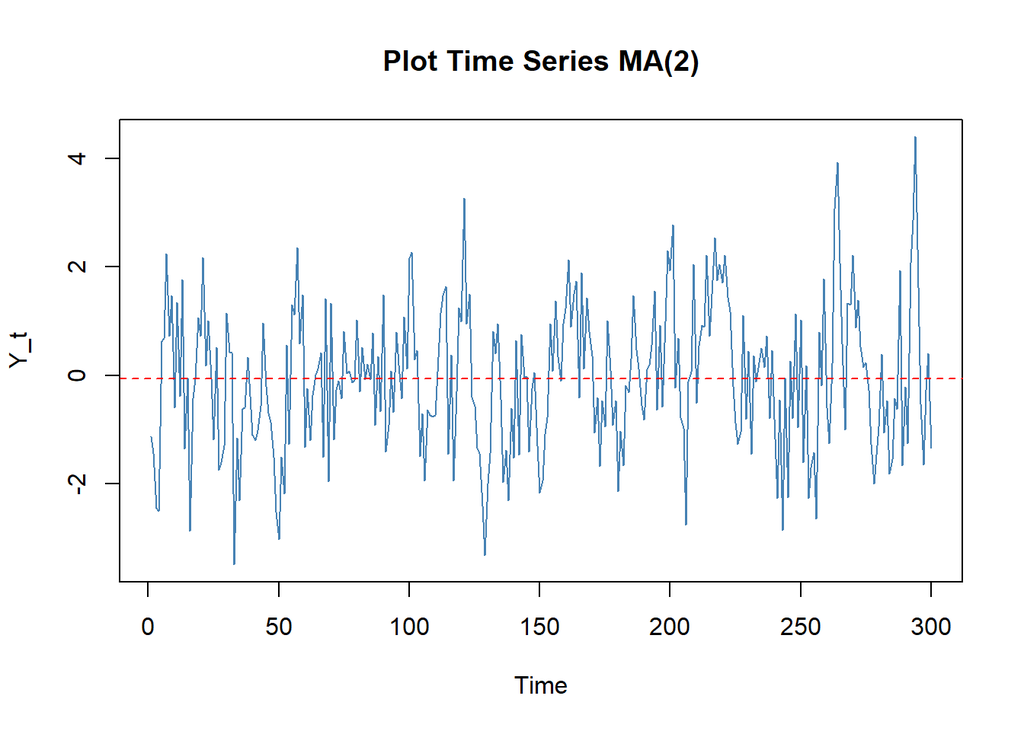

```r
data_ma2 <- manual

plot.ts(data_ma2, main="Plot Time Series MA(2)", ylab = "Y_t", col = "steelblue")
abline (h=mean(data_ma2), col = "red", lty=2)
```

Berdasarkan plot time series, terlihat bahwa data MA(2) hasil bangkitan stasioner. Hal ini karena fluktuasi data bergerak secara konsisten di garis rata-rata dan varians data juga relatif konstan.

## Plot ACF

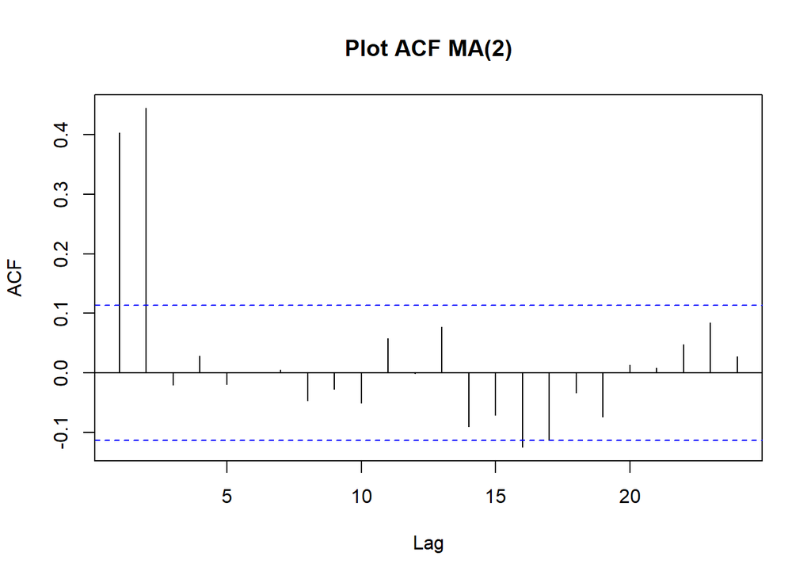

```r
acf(data_ma2, main="Plot ACF MA(2)")
```

## Plot PACF

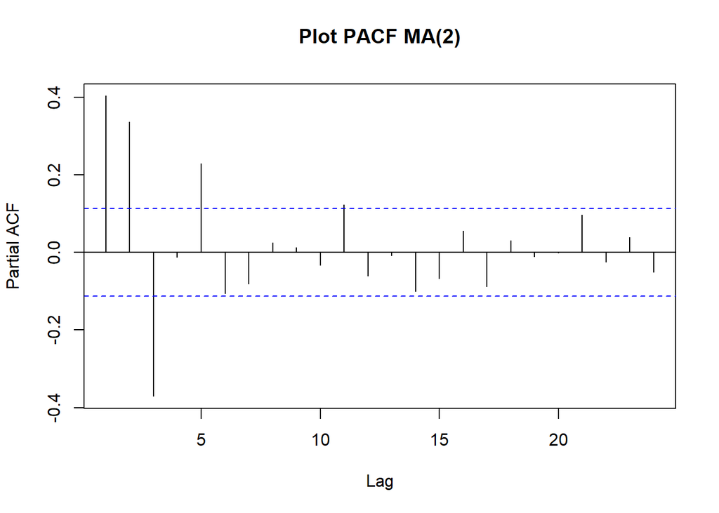

```r
pacf(data_ma2, main = "Plot PACF MA(2)")
```

Berdasarkan plot PACF, terlihat bahwa data stasioner karena nilai PACF menurun secara eksponensial.

## Plot EACF

```r
TSA::eacf(data_ma2)
```

```
## AR/MA
##   0 1 2 3 4 5 6 7 8 9 10 11 12 13
## 0 x x o o o o o o o o o  o  o  o
## 1 x x x o o o o o o o o  o  o  x
## 2 x x o o o o o o o o o  o  o  o
## 3 o x x o o o o o o o o  o  o  x
## 4 o x x o o o o o o o o  o  o  x
## 5 x x o o o o o o o o o  o  o  x
## 6 x x o x x x o o o o o  o  o  x
## 7 x x x o x x o o o o o  o  o  o
```

Berdasarkan plot EACF, data bangkitan tergolong pada data stasioner, karena adanya segitiga nol pada ordo AR (0) dan MA (2)

## Scatterplot antar Lag

```r
### Antara $Y_t$ dengan $Y_t-1$
```

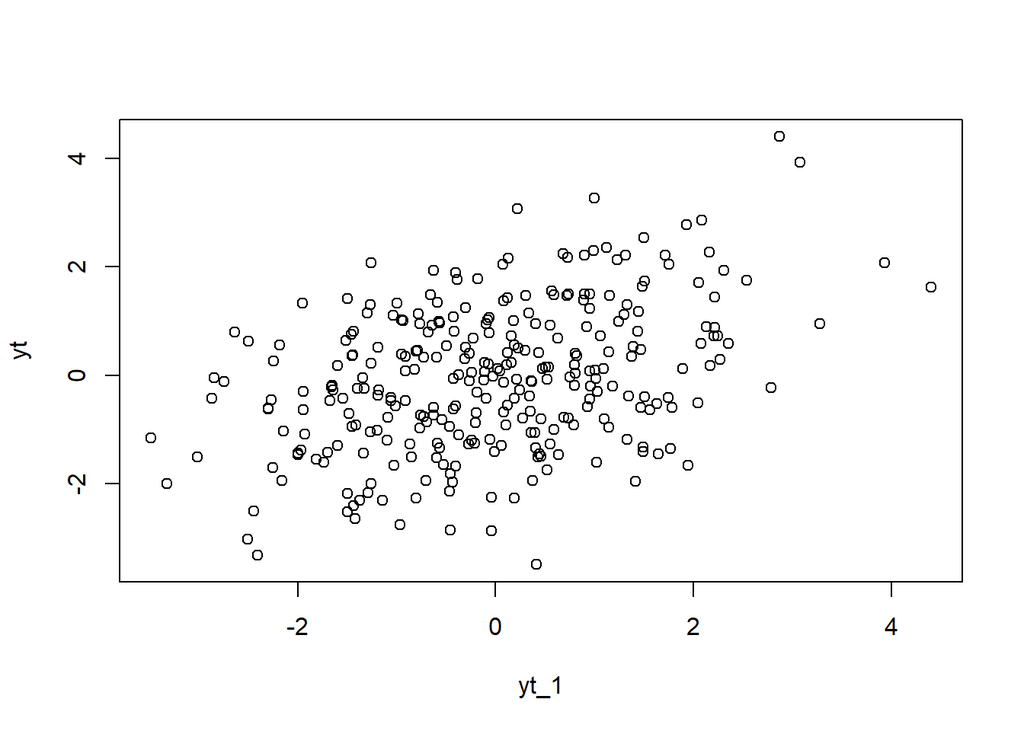

```r
yt <-data_ma2[4:n]
yt_1 <-data_ma2[3:(n-1)]

plot(y=yt, x=yt_1)
```

Berdasarkan scatterplot diatas, terlihat bahwa adanya korelasi positif antara $Y_t$ dengan $Y_(t-1)$

```r
### Antara $Y_t$ dengan $Y_t-2$
```

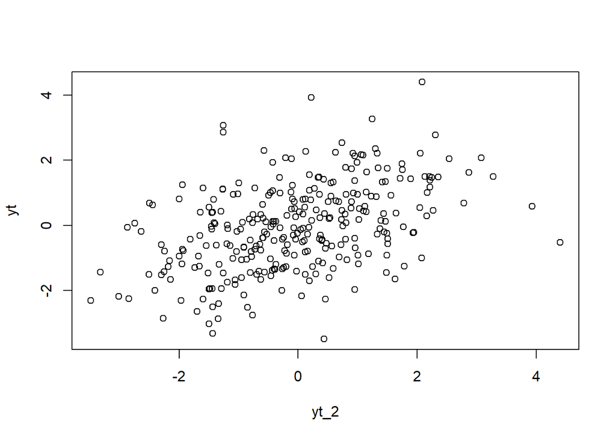

```r
yt_2<- data_ma2[2:(n-2)]

plot(y=yt, x=yt_2)
```

Berdasarkan scatterplot diatas, terlihat bahwa adanya korelasi positif antara $Y_t$ dengan $Y_(t-2)$

```r
### Antara $Y_t$ dengan $Y_t-3$
```

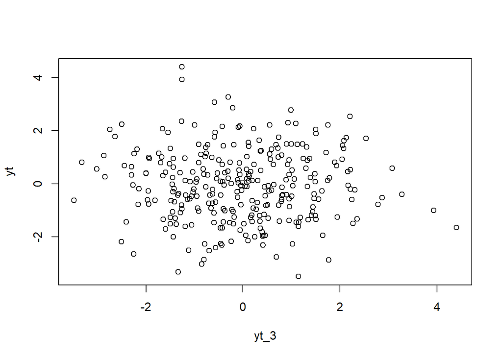

```r
yt_3 <- data_ma2[1:(n-3)]

plot(y=yt, x=yt_3)
```

Berdasarkan scatterplot diatas, terlihat bahwa titik menyebar secara acak dan menumpuk di sekitar 0. Hal ini menunjukkan tidak adanya korelasi antara $Y_t$ dengan $Y_(t-3)$

## Autokorelasi Data Bangkitan

```r
r_data_bangkitan<- acf(data_ma2, lag.max=3, plot = FALSE)$acf[,,1]
r_data_bangkitan
```

```
## [1]  0.40307182  0.44446672 -0.02068844
```

## Autokorelasi Teoritis

```r
denom <- 1+theta1^2+theta2^2
rho0_teoritis <- 1
rho1_teoritis <- (theta1+theta1*theta2)/denom
rho2_teoritis <- theta2/denom
rho3_teoritis <- 0

r_teoritis <- c(rho0_teoritis,rho1_teoritis, rho2_teoritis,rho3_teoritis)
r_teoritis
```

```
## [1] 1.0000000 0.4210526 0.3947368 0.0000000
```

Nilai autokorelasi data bangkitan telah mendekati pola nilai teoritisnya.

# Proses AR(2)

```r
set.seed(129)

n<- 300
phi1 <- 0.5
phi2 <- 0.2
```

## Pembangkitan Manual

```r
e<- rnorm(n, mean = 0, sd=1)
ar2_manual <- numeric(n)

ar2_manual [1] <- e[1]
ar2_manual[2]<- phi1* ar2_manual[1] +e[2]

for (t in 3:n){
  ar2_manual[t]<- phi1 * ar2_manual[t-1] +phi2* ar2_manual[t-2] + e[t]
}
ar2_manual
```

```
##   [1] -1.12090003 -1.55017451 -2.37396426 -2.85266211  0.09563144  0.17315333
##   [7]  0.87767098  0.47061946  1.41939250 -0.18645976  1.32242090  0.37898962
##  [13]  1.64060391 -0.77543701 -0.14159691 -2.05725133 -0.69807847  0.13114933
##  [19]  0.41576008  0.23412039  2.07566299  0.51937519  0.78577475  0.73534362
##  [25] -0.82253887  0.65008828 -1.13236528 -2.06505230 -1.13071128  1.09229124
##  [31] -0.14950752 -0.49627902 -3.22458732 -1.29413322 -1.98685506 -1.84925951
##  [37] -1.25888134 -0.32638791 -1.09668373 -1.84391376 -1.44032418 -1.24438707
##  [43] -1.23543744  0.31718622 -0.56314686 -1.43340125 -0.90987200 -1.47707255
##  [49] -3.08600929 -3.54356163 -1.90490477 -3.01261837 -1.08250878 -1.92323573
##  [55] -0.04774285  0.72504156  1.57532514  0.35594291  1.48339511 -0.56292164
##  [61] -0.26768283 -0.49783432 -0.40194461 -0.09086358 -0.02974752  0.22912142
##  [67] -1.55468067  1.19006990 -1.43441782  0.38314438 -0.58765199 -0.80035002
##  [73] -0.08130354 -0.44345081  0.40541355  0.04705105 -0.17152892 -0.04713912
##  [79]  0.01214303  0.98141201 -0.24395283  0.29512513  0.37836512  0.21658521
##  [85] -0.03793399  0.92242063 -0.68735738  0.11152216 -0.16075600  1.29934692
```

[output cut: 35 more lines]

## Pembangkitan dengan arima.sim

```r
ar2_sim <- arima.sim(model=list(ar=c(phi1, phi2)), n=n)
ar2_sim
```

```
## Time Series:
## Start = 1
## End = 300
## Frequency = 1
##   [1] -1.262314106 -0.029832664  1.986575819  0.485541033  1.719021503
##   [6]  1.157188008 -0.203482858 -0.981235945 -0.971177141 -1.939460436
##  [11] -0.178773638  0.982864788  1.039699859  0.271420801  0.469679842
##  [16]  1.757173951  0.621507900  0.742539881  1.629205667  0.082216383
##  [21]  1.048842417  1.189569252  0.850101915  1.661564184  1.446745880
##  [26]  0.823174691  0.490080267 -1.163027405  0.322924340 -2.840022475
##  [31] -0.389202638 -0.058741217 -1.200480621 -2.860699498 -1.672613672
##  [36] -0.092739332  1.693487184  1.436604046  1.713938792  2.288927902
##  [41]  2.218758657  0.839184626  0.072641617 -0.249304372 -0.742210400
##  [46] -2.071607081 -1.198989229 -0.684231682 -0.098399663  0.411923719
##  [51] -0.350730238 -1.296305491 -1.120720922 -1.738584155 -0.072264986
```

[output cut: 49 more lines]

## Plot Time Series

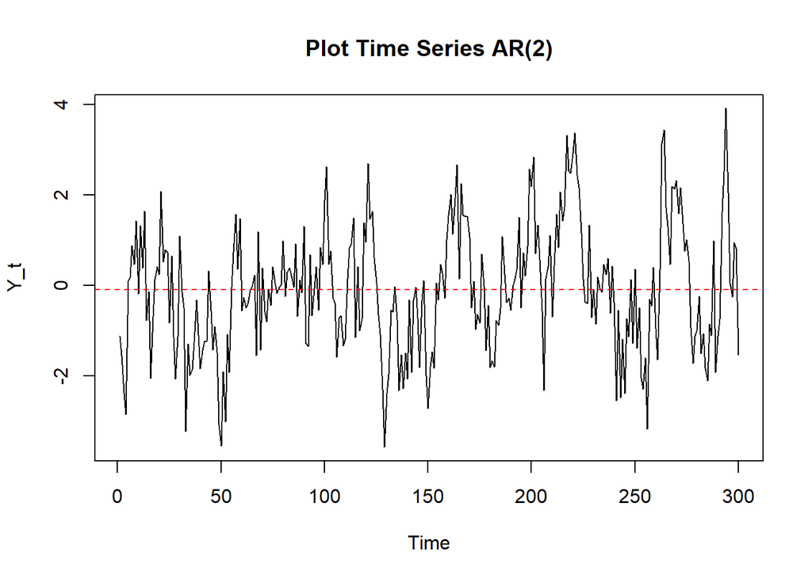

```r
ar2<- ar2_manual
plot.ts(ar2, main = "Plot Time Series AR(2)", ylab = "Y_t")
abline (h=mean(ar2), col = "red", lty=2)
```

Berdasarkan plot time series AR(2), terlihat bahwa fluktuasi data bergerak cenderung konstan dalam rataan dan ragam. Hal ini menunjukkan bahwa data stasioner.

## Plot ACF

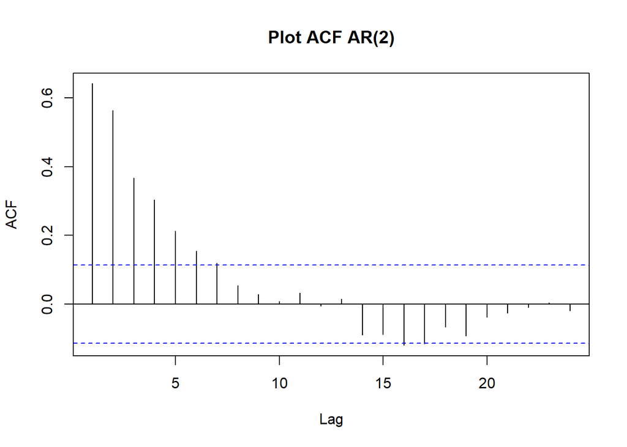

```r
acf(ar2, main ="Plot ACF AR(2)")
```

Berdasarkan ACF AR(2), terlihat bahwa adanya tails off seiring bertambahnya lag. Hal ini menunjukkan bahwa data stasioner.

## Plot PACF

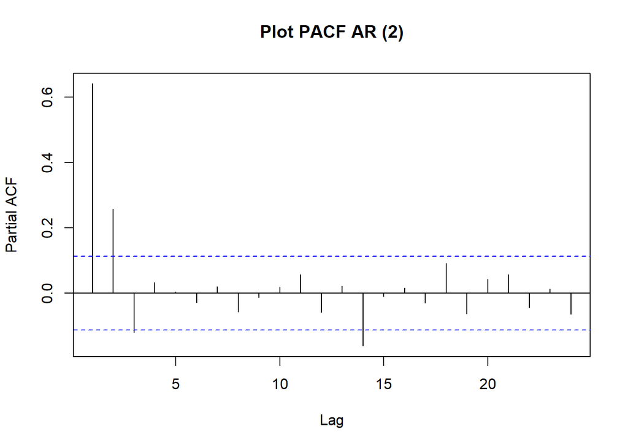

```r
pacf(ar2, main ="Plot PACF AR (2)")
```

Berdasarkan plot PACF AR(2), terlihat adanya cut off dari lag 3. Hal ini menunjukkan bahwa data stasioner

## Plot EACF

```r
eacf(ar2)
```

```
## AR/MA
##   0 1 2 3 4 5 6 7 8 9 10 11 12 13
## 0 x x x x x x x o o o o  o  o  o
## 1 x x x o o o o o o o o  o  o  x
## 2 x o o o o o o o o o o  o  o  x
## 3 x x o o o o o o o o o  o  o  x
## 4 o o o o o o o o o o o  o  o  o
## 5 o x x o o o o o o o o  o  o  o
## 6 x x o o o o o o o o o  o  o  o
## 7 x x x x o o o o o o o  o  o  o
```

Berdasarkan plot eacf di atas, terlihat bahwa data stasioner

## Scatterplot antar Lag

```r
### Antara $Y_t$ dengan $Y_t-1$
```

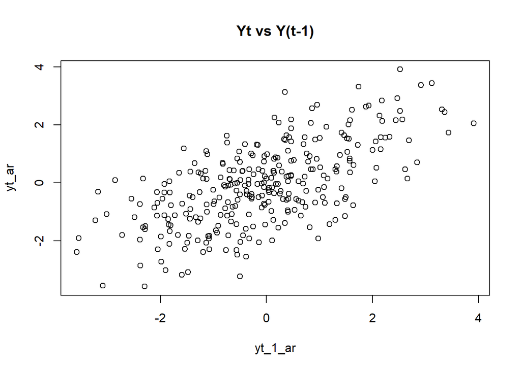

```r
yt_ar<- ar2[4:n]
yt_1_ar <- ar2[3:(n-1)]

plot(y=yt_ar, x=yt_1_ar, main ="Yt vs Y(t-1)")
```

```r
### Antara $Y_t$ dengan $Y_t-2$
```

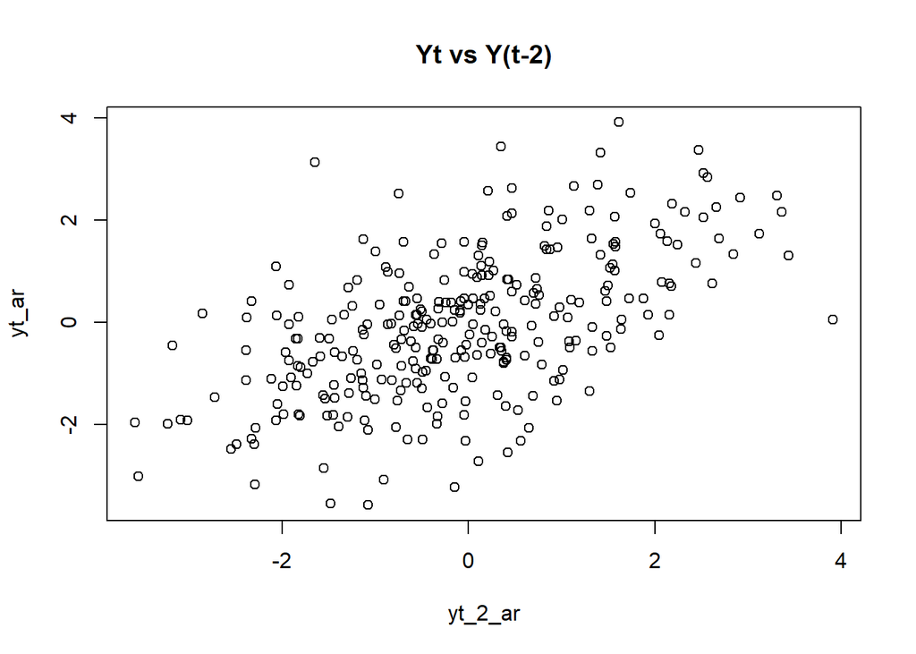

```r
yt_2_ar<- ar2[2:(n-2)]
plot(y=yt_ar, x=yt_2_ar, main = "Yt vs Y(t-2)")
```

```r
### Antara $Y_t$ dengan $Y_t-3$
```

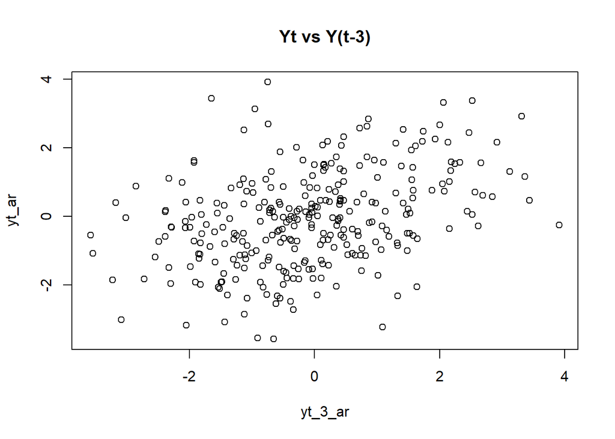

```r
yt_3_ar <- ar2[1:(n-3)]

plot(y=yt_ar, x=yt_3_ar, main = "Yt vs Y(t-3)")
```

Berdasarkan scatterplot antarlag, terlihat bahwa adanya korelasi positif antara Y dengan lag 1,2, maupun 3.

## Autokorelasi Data Bangkitan

```r
r_databangkitan_ar <- acf(ar2, lag.max = 3, plot = FALSE)$acf[,,1]
r_databangkitan_ar
```

```
## [1] 0.6410886 0.5626687 0.3665528
```

## Autokorelasi Teoritis

```r
rho0_teoritis_ar<- 1
rho1_teoritis_ar<- phi1/(1-phi2)
rho2_teoritis_ar <- phi1 *rho1_teoritis_ar+phi2
rho3_teoritis_ar <- phi1 * rho2_teoritis_ar+phi2*rho1_teoritis_ar

r_teoritis_ar<- c(rho0_teoritis_ar, rho1_teoritis_ar, rho2_teoritis_ar, rho3_teoritis_ar)

r_teoritis_ar
```

```
## [1] 1.00000 0.62500 0.51250 0.38125
```

Berdasarkan hasil autokorelasi, terlihat bahwa autokorelasi data bangkitan sudah mendekati dan cenderung mengikuti pola autokorelasi teoritis

# Proses ARMA(2,2)

```r
set.seed(129)

n<- 300
teta1 <- 0.4
teta2 <- 0.6
phi1 <- 0.5
phi2 <- 0.2
```

## Pembangkitan Manual

```r
e <- rnorm(n, mean=0, sd=1)
arma22_manual <- numeric(n)

arma22_manual [1]<-e[1]
arma22_manual [2] <- phi1*arma22_manual[1]+e[2]+teta1*e[1]

for(t in 3:n){
  arma22_manual[t]<- phi1*arma22_manual[t-1]+phi2*arma22_manual[t-2] + e[t]+teta1 *e[t-1] +teta2*e[t-2]
}
arma22_manual
```

```
##   [1] -1.120900031 -1.998534524 -3.666574080 -4.732352523 -2.469811964
##   [6] -1.500191368  1.004311174  0.925579852  2.134242871  0.663668920
##  [11]  2.099472493  0.796082125  2.585652295  0.108198330  0.532590635
##  [16] -2.579152296 -1.605937142 -1.382432855  0.049372734  0.479114024
##  [21]  2.418767192  1.490112624  2.238922620  1.361278637 -0.056936568
##  [26]  0.762278903 -1.365853286 -2.127945440 -2.636151368 -0.599024649
##  [31] -0.391017797  0.099292718 -3.512803437 -2.881735559 -4.439260736
##  [36] -3.420481466 -3.190698178 -1.939496149 -1.982567698 -2.478419999
##  [41] -2.835899927 -2.926865005 -2.597386782 -0.923620997 -1.177534834
##  [46] -1.468348263 -1.821120620 -2.701062101 -4.222761512 -5.664208875
##  [51] -5.173934998 -5.900717255 -3.430498987 -4.163810261 -1.466542404
##  [56] -0.447997014  1.836696055  1.421097901  2.570967361  0.244002150
##  [61]  0.397185580 -0.942660439 -0.761688041 -0.550342023 -0.307259721
##  [66]  0.162704264 -1.480880617  0.705670480 -1.891198271  0.523419185
##  [71] -1.295044930 -0.805524191 -0.754034743 -0.956182243  0.179251099
```

[output cut: 45 more lines]

## Pembangkitan dengan arima.sim

```r
arma22_sim<- arima.sim(model=list(ar=c(phi1, phi2), ma=c(teta1, teta2)), n=n)
arma22_sim
```

```
## Time Series:
## Start = 1
## End = 300
## Frequency = 1
##   [1]  1.217812051  1.262696970  3.105507564  2.136368349  1.290993638
##   [6] -0.368172664 -1.485651746 -2.916589392 -1.537200466 -0.252272420
##  [11]  1.325618572  1.277047810  1.202089570  2.107914753  1.606197876
##  [16]  2.045456934  2.299133618  1.179428112  2.059256589  1.658439265
##  [21]  1.955237517  2.715348370  2.621434127  2.398812640  1.687398500
##  [26] -0.473089852  0.151762020 -3.408668815 -1.331456744 -1.918435544
##  [31] -1.457498528 -3.376136353 -3.537181749 -2.478204428  0.652823302
##  [36]  2.058355361  3.304672753  3.836465870  4.162693112  3.100044844
##  [41]  1.739570673  0.283263059 -0.798347172 -2.518073860 -2.472958298
##  [46] -2.406791619 -1.091485871 -0.037975154 -0.245000547 -1.189443354
##  [51] -1.849681261 -2.964655817 -1.440131200 -2.552371038 -1.340105252
```

[output cut: 49 more lines]

## Plot Time Series ARMA(2,2)

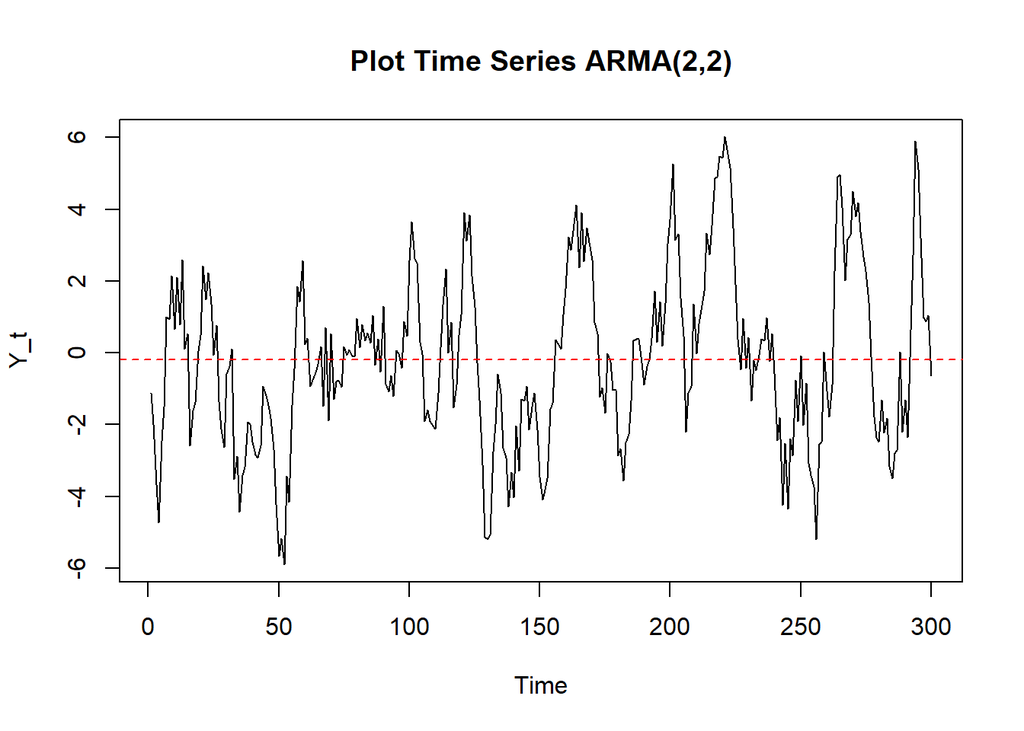

```r
data_arma22 <- arma22_manual
plot.ts(data_arma22, main = "Plot Time Series ARMA(2,2)", ylab = "Y_t")
abline(h = mean(data_arma22), col = "red", lty = 2)
```

Berdasarkan plot time series arma di atas, terlihat bahwa fluktuasi nya bergerak di sekitar rataan dan ragam. Maka dapat dikatakan bahwa data stasioner.

## Plot ACF ARMA(2,2)

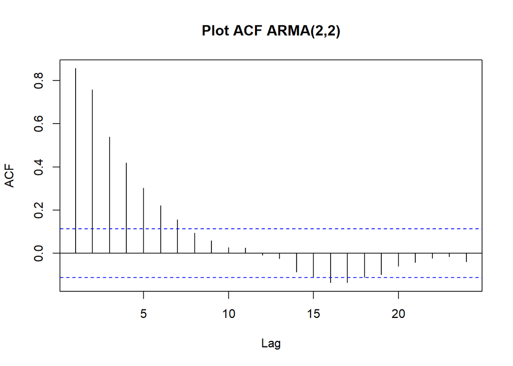

```r
acf(data_arma22, main = "Plot ACF ARMA(2,2)")
```

Berdasarkan plot ACF ARMA(2,2), terlihat bahwa nilai autokorelasinya menurun secara eksponensial (adanya tails off). Dengan ini, dapat dinyatakan bahwa data stasioner.

## Plot PACF ARMA(2,2)

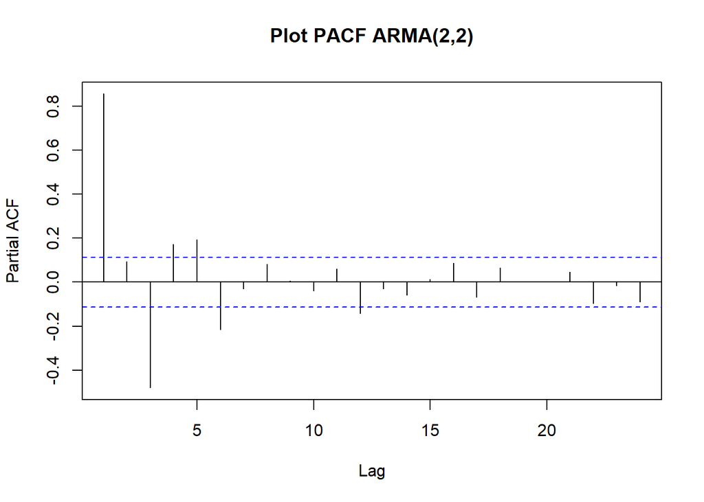

```r
pacf(data_arma22, main ="Plot PACF ARMA(2,2)")
```

## Plot EACF ARMA(2,2)

```r
eacf(data_arma22)
```

```
## AR/MA
##   0 1 2 3 4 5 6 7 8 9 10 11 12 13
## 0 x x x x x x x o o o o  o  o  o
## 1 o x x o o o o o o o o  o  o  x
## 2 x x x o o o o o o o o  o  o  x
## 3 x x x o o o o o o o o  o  o  x
## 4 x x x o o x o o o o o  o  o  o
## 5 x x x x o x o o o o o  o  o  x
## 6 x x o o x x o o o o o  o  x  o
## 7 x x o o o x o o o o o  o  x  o
```

## Scatterplot antar lag

```r
### Antara $Y_t$ dengan $Y_t-1$
```

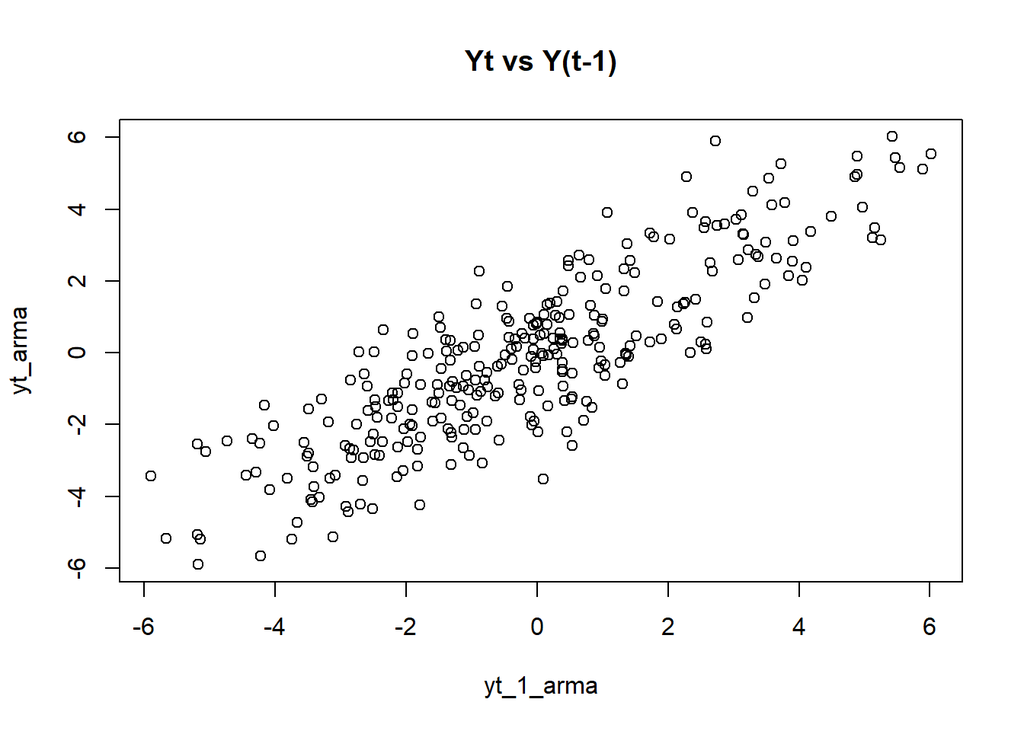

```r
yt_arma <- data_arma22[4:n]
yt_1_arma <- data_arma22[3:(n-1)]
plot(y=yt_arma, x = yt_1_arma, main ="Yt vs Y(t-1)")
```

```r
### Antara $Y_t$ dengan $Y_t-2$
```

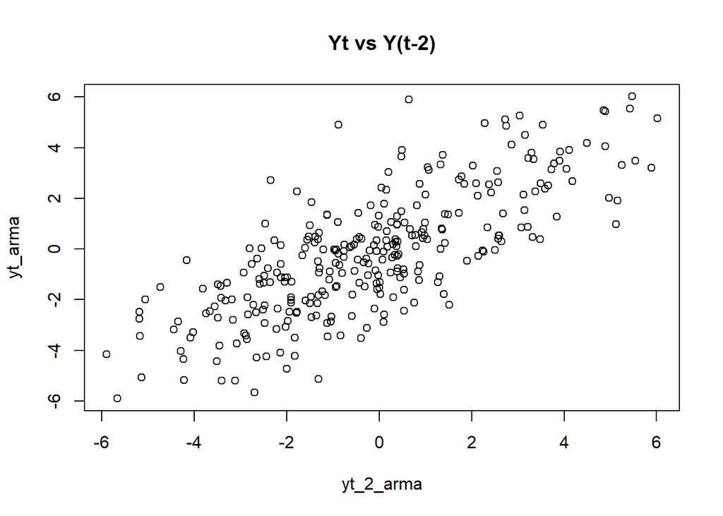

```r
yt_2_arma <- data_arma22[2:(n-2)]
plot(y=yt_arma, x= yt_2_arma, main ="Yt vs Y(t-2)")
```

```r
### Antara $Y_t$ dengan $Y_t-3$
```

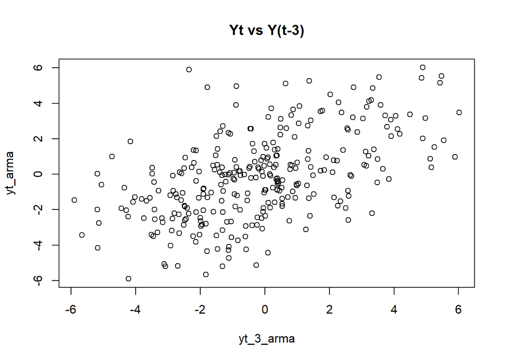

```r
yt_3_arma <- data_arma22[1:(n-3)]

plot(y=yt_arma, x = yt_3_arma, main = "Yt vs Y(t-3)")
```

Berdasarkan ketiga scatterplot antar lag, terlihat bahwa setiap lag memiliki korelasi positif dengan Yt.

## Autokorelasi data bangkitan ARMA(2,2)

```r
r_databangkitan_arma<- acf(data_arma22, lag.max = 3, plot = FALSE)$acf[,,1]
r_databangkitan_arma
```

```
## [1] 0.8555017 0.7566554 0.5390515
```

## Autokorelasi Teoritis ARMA(2,2)

```r
r_teoritis_arma <- ARMAacf(
  ar=c(phi1, phi2),
  ma=c(teta1, teta2),
  lag.max=3
)
r_teoritis_arma
```

```
##         0         1         2         3
## 1.0000000 0.8591993 0.7491908 0.5464353
```

Berdasarkan nilai autokorelasi, didapatkan bahwa autokorelasi data bangkitan cenderung mendekati dan mengikuti pola autokorelasi teoritis pada ARMA(2,2).